# Student Loan Relief Report

Amy Yates

# Background

As the cost of higher education continues to grow, student debt in America rose to $1.6 trillion in 2022, impacting 45 million individuals and their families<sup>1</sup>. In August of 2022, the Biden Administration announced a debt relief program<sup>2</sup> of $10000 for borrowers below a certain income level and $20000 for borrowers that had received Pell Grants. This initiative is currently blocked by courts, and monthly payments are paused until August of 2023 if litigation does not resolve sooner.

This report will explore higher education data to try and answer the following questions:

1. What are the characteristics of borrowers (demographics, income level, institutions, post-graduate level)?
2. Under the proposed plan, which borrowers are most positively impacted?
3. Is the income level cap of $125,000 per individual/$250,000 per family backed by data?
4. Can we identify recommendations for changes to the plan?

Some of the data available that may be explored is listed below:

- https://nces.ed.gov/ipeds/datacenter/DataFiles.aspx?year=2001
- https://github.com/rfordatascience/tidytuesday/tree/master/data/2019/2019-11-26
- https://tuitiontracker.org/
- https://data.ed.gov/dataset/federal-student-loan-portfolio/resources

# Pell Grant Data

*Source: https://github.com/rfordatascience/tidytuesday/tree/master/data/2022/2022-08-30*

Pell Grants are provided to students that meet certain qualifications for financial need. These are grants, not loans, and do not require repayment. These grants typically make only a small dent in the overall cost, so most students accepting Pell Grants also take out loans. Qualification for these grants serve as an indicator that these students lack the generational wealth that many college-bound individuals enjoy and that loan forgiveness would make a greater impact for them.

The average grant amount can vary widely by institution and by state. Since the federal grant program does not consider institutional cost, it is expected that income level of applicants is the main contributor to the variance. However, different institutions may offer better support for accessing these grants.

Below is a summary of the 2017 averages per state, ordered from the largest total per recipient down.

Top Ten Per Capita Pell Grant States

2017

| state | year | award_total | recipient_total | total_per_recipient |
| --- | --- | --- | --- | --- |
| PR | 2017 | $814,593,716 | 178098 | $4,574 |
| AS | 2017 | $4,181,457 | 929 | $4,501 |
| MS | 2017 | $341,473,115 | 75904 | $4,499 |
| VI | 2017 | $4,418,901 | 1004 | $4,401 |
| NY | 2017 | $1,985,470,926 | 452331 | $4,389 |
| MP | 2017 | $4,261,741 | 980 | $4,349 |
| FM | 2017 | $9,945,871 | 2320 | $4,287 |
| MH | 2017 | $5,223,129 | 1220 | $4,281 |
| AR | 2017 | $270,693,698 | 64697 | $4,184 |
| NJ | 2017 | $666,368,206 | 160110 | $4,162 |

Six of the top ten states are in fact territories of the U.S. with Puerto Rico topping the list. This strengthens the supposition that populations with lower income levels are the primary contributor to larger individual grants. The top ten also includes New York and New Jersey, however, states that were in the top 1/3 of incomes in that same year.

To understand why that might be, let’s take a look at the New York grants at an institutional level, ordering from high to low.

Top Ten Per Capita Pell Grant Institutions in New York (2017)

NY Recipient Average $4389

| **State** | **Name** | **Institution Per Recipient** |
| --- | --- | --- |
| NY | Elyon College | $8,773 |
| NY | Be'er Yaakov Talmudic Seminary | $8,219 |
| NY | Yeshiva Shaar Ephraim | $8,073 |
| NY | United Talmudical Seminary | $7,678 |
| NY | Mesivta Eastern Pkwy Rabbinical Clg | $7,470 |
| NY | Rabbinical College of Long Island | $7,218 |
| NY | Mechon L'hoyroa | $6,918 |
| NY | Bet Medrash Gadol Ateret Torah | $6,914 |
| NY | Beth Hatalmud Rabbinical Clg | $6,673 |
| NY | Ohr Hameir Theological Seminary | $6,559 |

# The Cost of Higher Education

Let’s next look at the cost of college, by using the website Tuition Tracker<sup>3</sup> which provides tuition information for over 3000 institutions. Let’s start by examining the published sticker price of 4-year institutions and looking only at the 2017-2018 academic year as we did for Pell Grants. For now, we’ll focus on students living on campus.

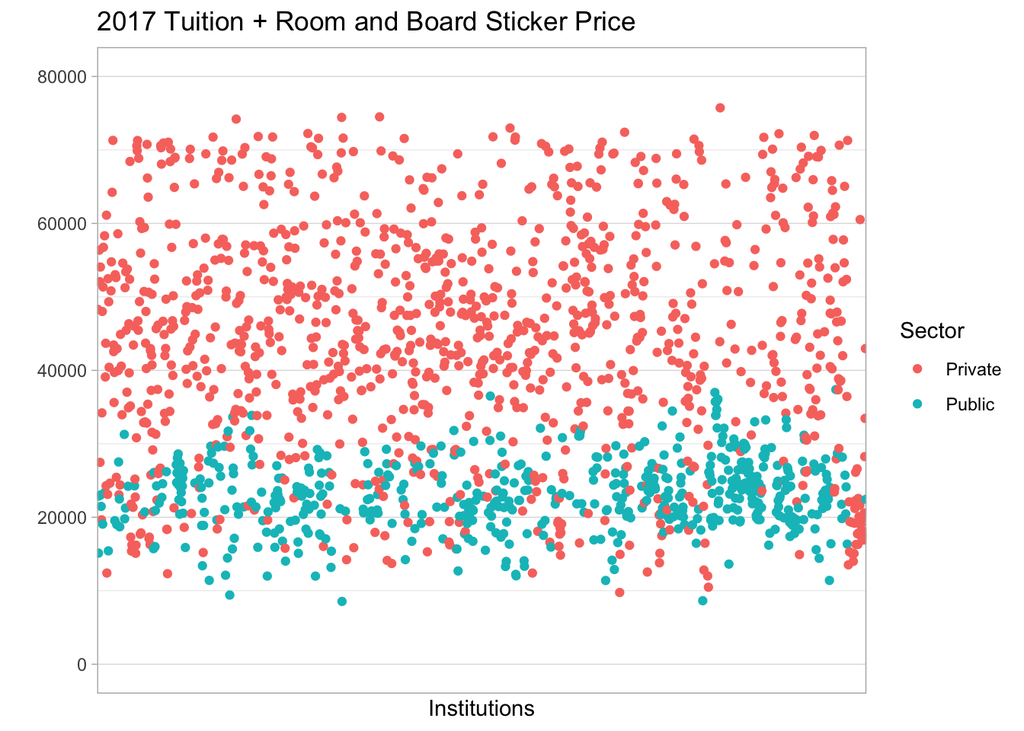

As expected, there is a huge disparity in the published price of public institutions versus private, with the private range being much larger. However, many private institutions claim to offer better financial assistance, with the majority of their scholars receiving some form of aid. Let’s next looks at the net price.

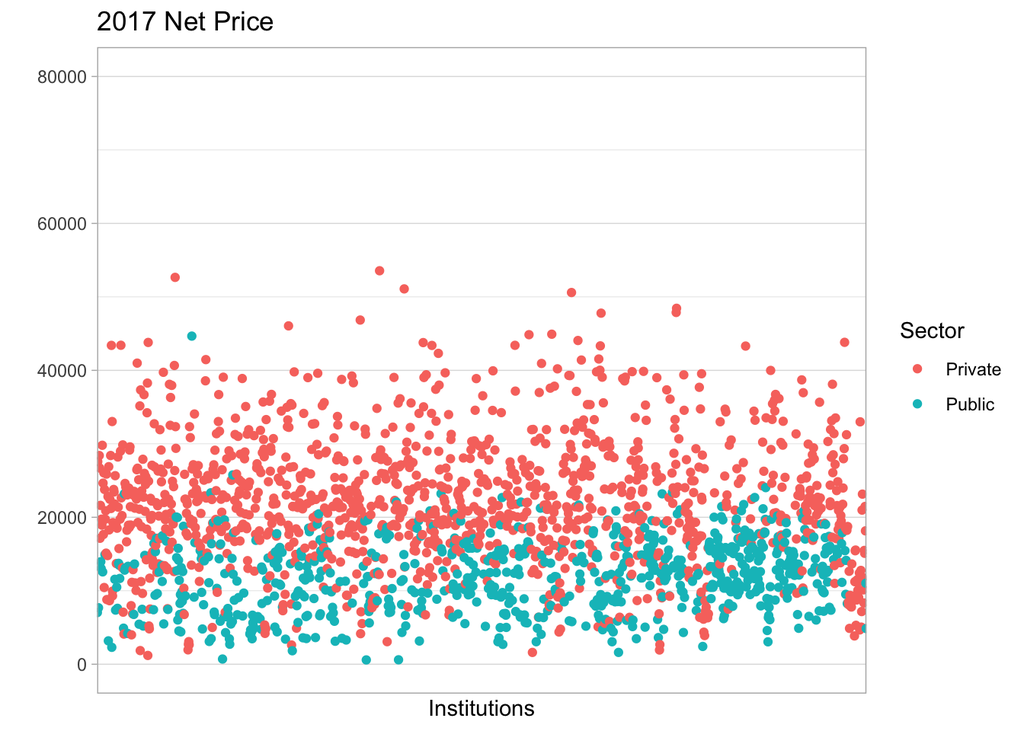

It appears that private institutions do start to narrow the gap when it comes to providing funding overall. How do institutions stack up when it comes to income levels? We’ll rearrange the data, so we can facet it and plots by income level.

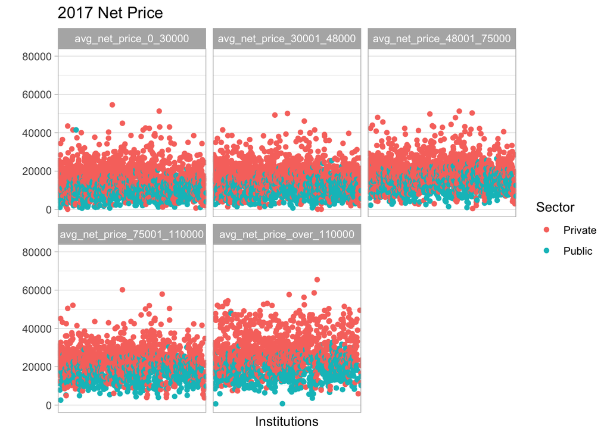

The scatterplot makes it difficult to discern any real differences in income brackets. Let’s instead look at the overall averages.

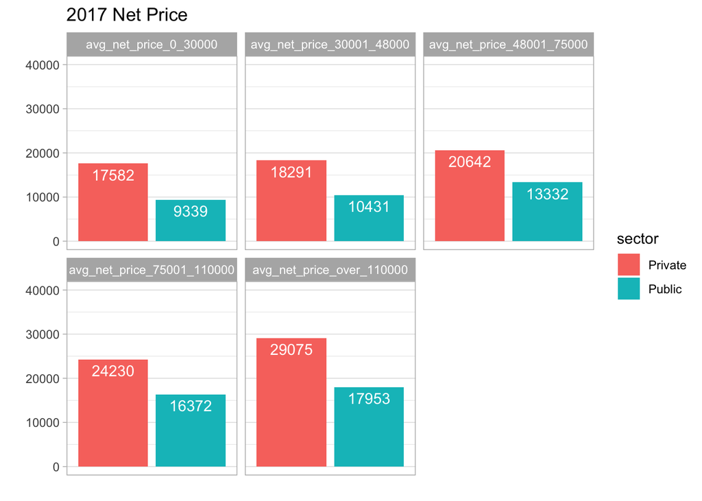

And finally, let’s reintroduce the sticker price to the graph to get a sense of what the discount looks like at each income bracket.

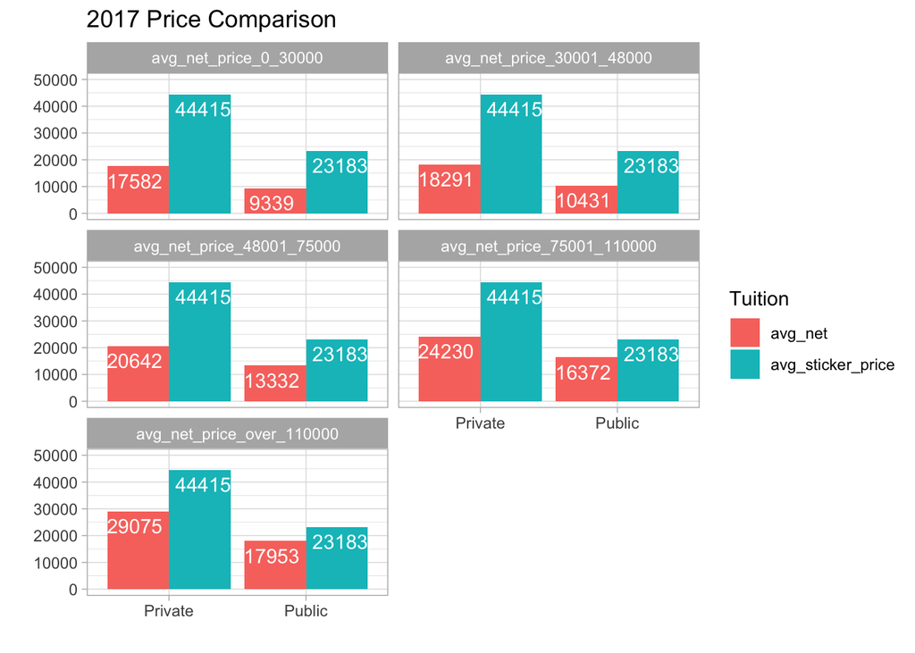

# References

1.

Koeze, E. & Russell, K. [The Toll of Student Debt in the U.S.](https://www.nytimes.com/interactive/2022/08/26/your-money/student-loan-forgiveness-debt.html) *The New York Times* (2022).

2.

[Federal Student Aid](https://studentaid.gov/debt-relief-announcement).

3.

[Tuition Tracker](http://www.tuitiontracker.org).